# filter_by_variant_effect_wecare_only_jan2017

started: Alexey Larionov, 2016  
last updated: Alexey Larionov, 06Mar2017

# Summary

220,812 -> 17,598 variants (8,766 genes)

### Including Loss of function variants

“splice_acceptor_variant”, “splice_donor_variant”, “stop_gain”, “stop_lost”, “start_lost”, “frameshift_variant” : 3,776 variants

### Including ClinSig variants

“likely_pathogenic”, “risk_factor”, “pathogenic”, “association”, “protective”, “drug_response”: 717 variants

### Total retained

**Variants:** 17,598  
**Genes:** 8,766  
~2 protein-affecting variants per gene

## NOT excluding variants with high AF in 1k

These are sequence versions from Ref genome, which ALTs are common in 1k:

EUR_AF>0.5: 147 from above selection  
EUR_AF>0.9: 19 from above selection (2,092 total in the whole variantset)

These sequences are preserved in this script.  
However, they will need special treatment in downstream analysis.

## NOT excluding multiallelic variaints

439 multiallelic varaints in selected  
(5,170 in the whole variantset)

# start_section

```r
# Start time
Sys.time()
```

```
## [1] "2017-03-06 22:17:04 GMT"
```

```r
# Folders
setwd("/scratch/medgen/scripts/wecare_stat_01.17/scripts")
interim_data_folder <- "/scratch/medgen/scripts/wecare_stat_01.17/interim_data"

# Load libraries
library(dplyr)
```

```r
library(reshape2) # for melt()
library(ggplot2)
library(VennDiagram)
```

# load_data

```r
# Load data
load(paste(interim_data_folder, "r06a_exclude_egenvectors_outliers_wecare_only_jan2017.RData", sep="/"))
```

# check_data

```r
ls()
```

```
## [1] "interim_data_folder"  "results_folder"       "wecare_exac.df"
## [4] "wecare_genotypes.mx"  "wecare_kgen.df"       "wecare_phenotypes.df"
## [7] "wecare_variants.df"
```

```r
dim(wecare_genotypes.mx)
```

```
## [1] 220812    474
```

```r
class(wecare_genotypes.mx)
```

```
## [1] "matrix"
```

```r
wecare_genotypes.mx[1:5,1:5]
```

```
##              P1_A01 P1_A02 P1_A03 P1_A04 P1_A05
## Var000000002      0      0      0      0      0
## Var000000008      0      0     NA      0     NA
## Var000000009      0     NA     NA      0     NA
## Var000000012      0     NA     NA      0      0
## Var000000013      0     NA      0      0      0
```

```r
dim(wecare_phenotypes.df)
```

```
## [1] 474  32
```

```r
str(wecare_phenotypes.df)
```

```
## 'data.frame':    474 obs. of  32 variables:
##  $ wes_id        : chr  "P1_A01" "P1_A02" "P1_A03" "P1_A04" ...
##  $ gwas_id       : chr  "id203568" "id357807" "id325472" "id304354" ...
##  $ merged_id     : chr  "P1_A01_id203568" "P1_A02_id357807" "P1_A03_id325472" "P1_A04_id304354" ...
##  $ filter        : chr  "pass" "pass" "pass" "pass" ...
##  $ cc            : num  1 1 1 1 1 1 0 1 1 0 ...
##  $ setno         : int  203568 357807 325472 304354 222648 244843 276284 297810 250898 226974 ...
##  $ registry      : chr  "IR" "LA" "IA" "IA" ...
##  $ family_history: int  1 0 1 1 1 1 1 1 1 0 ...
##  $ age_dx        : int  49 35 32 33 44 28 28 38 35 36 ...
##  $ age_ref       : num  58 36 41 34 49 28 32 44 35 38 ...
##  $ rstime        : num  10.17 1.83 9.75 1.59 5.66 ...
##  $ eig1_gwas     : num  -0.00389 -0.00379 -0.01011 -0.01288 -0.01086 ...
##  $ eig2_gwas     : num  0.00266 0.00246 -0.0001 0.00595 0.01157 ...
##  $ eig3_gwas     : num  0.06803 0.05055 -0.00603 0.00747 0.00144 ...
```

[output cut: 18 more lines]

```r
wecare_phenotypes.df[1:5,1:5]
```

```
##        wes_id  gwas_id       merged_id filter cc
## P1_A01 P1_A01 id203568 P1_A01_id203568   pass  1
## P1_A02 P1_A02 id357807 P1_A02_id357807   pass  1
## P1_A03 P1_A03 id325472 P1_A03_id325472   pass  1
## P1_A04 P1_A04 id304354 P1_A04_id304354   pass  1
## P1_A05 P1_A05 id222648 P1_A05_id222648   pass  1
```

```r
dim(wecare_variants.df)
```

```
## [1] 220812     44
```

```r
colnames(wecare_variants.df)
```

```
##  [1] "SplitVarID"         "SYMBOL"             "TYPE"
##  [4] "CHROM"              "POS"                "REF"
##  [7] "ALT"                "AC"                 "AF"
## [10] "AN"                 "Consequence"        "SIFT_call"
## [13] "SIFT_score"         "PolyPhen_call"      "PolyPhen_score"
## [16] "CLIN_SIG"           "cDNA_position"      "CDS_position"
## [19] "Codons"             "Protein_position"   "Amino_acids"
## [22] "Existing_variation" "Multiallelic"       "ac_wecare_cln"
## [25] "an_wecare_cln"      "af_wecare_cln"      "ac_ubc_cln"
## [28] "an_ubc_cln"         "af_ubc_cln"         "ac_cbc_cln"
## [31] "an_cbc_cln"         "af_cbc_cln"         "ac_ubc_fam_cln"
## [34] "an_ubc_fam_cln"     "af_ubc_fam_cln"     "ac_ubc_nofam_cln"
## [37] "an_ubc_nofam_cln"   "af_ubc_nofam_cln"   "ac_cbc_fam_cln"
## [40] "an_cbc_fam_cln"     "af_cbc_fam_cln"     "ac_cbc_nofam_cln"
## [43] "an_cbc_nofam_cln"   "af_cbc_nofam_cln"
```

```r
wecare_variants.df[1:5,1:5]
```

```
##                SplitVarID    SYMBOL  TYPE CHROM    POS
## Var000000002 Var000000002 LINC00115   SNP     1 762330
## Var000000008 Var000000008    SAMD11   SNP     1 871215
## Var000000009 Var000000009    SAMD11   SNP     1 871230
## Var000000012 Var000000012    SAMD11 INDEL     1 874778
## Var000000013 Var000000013    SAMD11   SNP     1 878664
```

```r
dim(wecare_kgen.df)
```

```
## [1] 220812      9
```

```r
colnames(wecare_kgen.df)
```

```
## [1] "SplitVarID"  "kgen.AC"     "kgen.AN"     "kgen.AF"     "kgen.AFR_AF"
## [6] "kgen.AMR_AF" "kgen.EAS_AF" "kgen.EUR_AF" "kgen.SAS_AF"
```

```r
wecare_kgen.df[1:5,1:5]
```

```
##                SplitVarID kgen.AC kgen.AN     kgen.AF kgen.AFR_AF
## Var000000002 Var000000002      NA      NA          NA          NA
## Var000000008 Var000000008      NA      NA          NA          NA
## Var000000009 Var000000009      NA      NA          NA          NA
## Var000000012 Var000000012      NA      NA          NA          NA
## Var000000013 Var000000013       2    5008 0.000399361           0
```

```r
dim(wecare_exac.df)
```

```
## [1] 220812     48
```

```r
colnames(wecare_exac.df)
```

```
##  [1] "SplitVarID"              "exac_non_TCGA.AF"
##  [3] "exac_non_TCGA.AC"        "exac_non_TCGA.AN"
##  [5] "exac_non_TCGA.AC_FEMALE" "exac_non_TCGA.AN_FEMALE"
##  [7] "exac_non_TCGA.AC_MALE"   "exac_non_TCGA.AN_MALE"
##  [9] "exac_non_TCGA.AC_Adj"    "exac_non_TCGA.AN_Adj"
## [11] "exac_non_TCGA.AC_Hom"    "exac_non_TCGA.AC_Het"
## [13] "exac_non_TCGA.AC_Hemi"   "exac_non_TCGA.AC_AFR"
## [15] "exac_non_TCGA.AN_AFR"    "exac_non_TCGA.Hom_AFR"
## [17] "exac_non_TCGA.Het_AFR"   "exac_non_TCGA.Hemi_AFR"
## [19] "exac_non_TCGA.AC_AMR"    "exac_non_TCGA.AN_AMR"
## [21] "exac_non_TCGA.Hom_AMR"   "exac_non_TCGA.Het_AMR"
## [23] "exac_non_TCGA.Hemi_AMR"  "exac_non_TCGA.AC_EAS"
## [25] "exac_non_TCGA.AN_EAS"    "exac_non_TCGA.Hom_EAS"
## [27] "exac_non_TCGA.Het_EAS"   "exac_non_TCGA.Hemi_EAS"
## [29] "exac_non_TCGA.AC_FIN"    "exac_non_TCGA.AN_FIN"
## [31] "exac_non_TCGA.Hom_FIN"   "exac_non_TCGA.Het_FIN"
## [33] "exac_non_TCGA.Hemi_FIN"  "exac_non_TCGA.AC_NFE"
## [35] "exac_non_TCGA.AN_NFE"    "exac_non_TCGA.Hom_NFE"
## [37] "exac_non_TCGA.Het_NFE"   "exac_non_TCGA.Hemi_NFE"
## [39] "exac_non_TCGA.AC_SAS"    "exac_non_TCGA.AN_SAS"
## [41] "exac_non_TCGA.Hom_SAS"   "exac_non_TCGA.Het_SAS"
## [43] "exac_non_TCGA.Hemi_SAS"  "exac_non_TCGA.AC_OTH"
## [45] "exac_non_TCGA.AN_OTH"    "exac_non_TCGA.Hom_OTH"
## [47] "exac_non_TCGA.Het_OTH"   "exac_non_TCGA.Hemi_OTH"
```

```r
wecare_exac.df[1:5,1:5]
```

```
##                SplitVarID exac_non_TCGA.AF exac_non_TCGA.AC
## Var000000002 Var000000002        0.0120000              175
## Var000000008 Var000000008               NA               NA
## Var000000009 Var000000009               NA               NA
## Var000000012 Var000000012               NA               NA
## Var000000013 Var000000013        0.0005838               62
##              exac_non_TCGA.AN exac_non_TCGA.AC_FEMALE
## Var000000002            14012                      59
## Var000000008               NA                      NA
## Var000000009               NA                      NA
## Var000000012               NA                      NA
## Var000000013           106198                      17
```

```r
# Check consistency of rownames and colnames
sum(colnames(wecare_genotypes.mx) != rownames(wecare_phenotypes.df))
```

```
## [1] 0
```

```r
sum(rownames(wecare_genotypes.mx) != rownames(wecare_variants.df))
```

```
## [1] 0
```

```r
sum(rownames(wecare_genotypes.mx) != rownames(wecare_kgen.df))
```

```
## [1] 0
```

```r
sum(rownames(wecare_genotypes.mx) != rownames(wecare_exac.df))
```

```
## [1] 0
```

# — explore_variants_annotations —

## explore_VEP_consequences

A combination of the below consequencies can be assigned to a variant

```r
sum(is.na(wecare_variants.df$Consequence)) # 0
```

```
## [1] 0
```

```r
a <- strsplit(as.vector(wecare_variants.df$Consequence),"&")
b <- unique(as.vector(unlist(a)))
b
```

```
##  [1] "non_coding_transcript_exon_variant"
##  [2] "non_coding_transcript_variant"
##  [3] "synonymous_variant"
##  [4] "inframe_deletion"
##  [5] "missense_variant"
##  [6] "stop_gained"
##  [7] "splice_region_variant"
##  [8] "intron_variant"
##  [9] "downstream_gene_variant"
## [10] "5_prime_UTR_variant"
## [11] "3_prime_UTR_variant"
## [12] "mature_miRNA_variant"
## [13] "inframe_insertion"
## [14] "upstream_gene_variant"
## [15] "splice_acceptor_variant"
## [16] "frameshift_variant"
## [17] "splice_donor_variant"
## [18] "stop_lost"
## [19] "intergenic_variant"
## [20] "start_lost"
## [21] "NMD_transcript_variant"
## [22] "stop_retained_variant"
## [23] "coding_sequence_variant"
## [24] "protein_altering_variant"
```

```r
rm(a,b)
```

## explore sift, polyphen, clin_sig

### Annotations seen in wecare

*SIFT:* “tolerated”, “deleterious”, “tolerated_low_confidence”, “deleterious_low_confidence”

*PolyPhen:* “benign”, “possibly_damaging”, “probably_damaging”, “unknown”

*CLIN_SIG:* “likely_benign”, “benign”, “likely_pathogenic”, “risk_factor”, “not_provided”, “uncertain_significance”, “pathogenic”, “association”, “protective”, “other”, “drug_response”

I have also seen “confers_sensitivity” in CLIN_SIG for gastric cases

### Interpreting SIFT and PolyPhen scores (not used here)

*SIFT:* the higher score the less deleterious  
*PolyPhen:* the higher score the more damaging

```r
# SIFT
unique(as.vector(wecare_variants.df$SIFT_call))
```

```
## [1] NA                           "tolerated"
## [3] "deleterious"                "tolerated_low_confidence"
## [5] "deleterious_low_confidence"
```

```r
# PolyPhen
unique(as.vector(wecare_variants.df$PolyPhen_call))
```

```
## [1] NA                  "benign"            "probably_damaging"
## [4] "possibly_damaging" "unknown"
```

```r
#CLIN_SIG
unique(unlist(strsplit(as.vector(wecare_variants.df$CLIN_SIG), split="\\&")))
```

```
##  [1] NA                       "benign"
##  [3] "likely_benign"          "likely_pathogenic"
##  [5] "uncertain_significance" "risk_factor"
##  [7] "not_provided"           "pathogenic"
##  [9] "drug_response"          "association"
## [11] "protective"             "other"
```

## count_variants_frequent_in_kgen_and_exac

2,092 rare sequence versions are present into reference genome (b37)  
~1% of all variants in the datset

Tehy will be preserbved; however they should be treated specially in downstream analyses because “variants” called in these sites represent sequence versions common in humans, despite the misleading “low” MAFs in some databases.

```r
x <- wecare_kgen.df  %>% filter(kgen.EUR_AF > 0.9) %>% select(SplitVarID)
length(x) # 2,092
```

```
## [1] 1
```

```r
y <- wecare_exac.df  %>% filter(exac_non_TCGA.AF > 0.9) %>% select(SplitVarID)
length(y) # 1,497
```

```
## [1] 1
```

```r
x <- as.character(x[,1])
y <- as.character(y[,1])
z <- intersect(x,y)
length(z) # 1,389
```

```
## [1] 1389
```

```r
rm(x,y,z)
```

## count_multiallelic_varaints

5,170 multiallelic varaints

```r
summary(wecare_variants.df$Multiallelic) # 5,170
```

```
##    Mode   FALSE    TRUE    NA's
## logical  215642    5170       0
```

# — Make indices —

## make_lof_index

```r
sum(is.na(wecare_variants.df$Consequence)) # 0
```

```
## [1] 0
```

```r
# --- Splice acceptor variants (sav) --- #

splice_acceptor_variant <- grepl( "splice_acceptor_variant", wecare_variants.df$Consequence)
sum(splice_acceptor_variant) # 317
```

```
## [1] 317
```

```r
# mean count of alleles per case in wecare
sav_wecare.mx <- wecare_genotypes.mx[splice_acceptor_variant,]
sav_wecare.counts <- apply(sav_wecare.mx, 2, sum, na.rm=TRUE)
sav_wecare.mean <- mean(sav_wecare.counts, na.rm=TRUE) # ~20
rm(sav_wecare.mx, sav_wecare.counts)

# --- Splice donor variants (sdv) --- #

splice_donor_variant <- grepl( "splice_donor_variant", wecare_variants.df$Consequence)
sum(splice_donor_variant) # 463
```

```
## [1] 463
```

```r
# mean count of alleles per case in wecare
sdv_wecare.mx <- wecare_genotypes.mx[splice_donor_variant,]
sdv_wecare.counts <- apply(sdv_wecare.mx, 2, sum, na.rm=TRUE)
sdv_wecare.mean <- mean(sdv_wecare.counts, na.rm=TRUE) # ~17
rm(sdv_wecare.mx, sdv_wecare.counts)

# --- Stop gains --- #

stop_gain <- grepl( "stop_gain", wecare_variants.df$Consequence)
sum(stop_gain) # 1,614
```

```
## [1] 1614
```

```r
# mean count of alleles per case in wecare
stogv_wecare.mx <- wecare_genotypes.mx[stop_gain,]
stogv_wecare.counts <- apply(stogv_wecare.mx, 2, sum, na.rm=TRUE)
stogv_wecare.mean <- mean(stogv_wecare.counts, na.rm=TRUE) # ~51
rm(stogv_wecare.mx, stogv_wecare.counts)

# --- Stop losts --- #

# Interestingly, there are much less of stop_losts than stop_gains: 56 and 1,168 respectively.
# This looks contraintuitive, suggesting that stop_gains are better tolerated than stop losses.
# In other words: stop_losses may be under stronger evolutionary control than stop_gains??

# An alternative explanation coulod be that stop losts can only happen on stop codons;
# while stop gain can happen in "any"" codon within the gene: so stop gains have much more chances to happen.

stop_lost <- grepl( "stop_lost", wecare_variants.df$Consequence)
sum(stop_lost) # 56
```

```
## [1] 56
```

```r
# mean count of alleles per case in wecare
stolv_wecare.mx <- wecare_genotypes.mx[stop_lost,]
stolv_wecare.counts <- apply(stolv_wecare.mx, 2, sum, na.rm=TRUE)
stolv_wecare.mean <- mean(stolv_wecare.counts, na.rm=TRUE) # ~14
rm(stolv_wecare.mx, stolv_wecare.counts)

# --- Start losts --- #

# Functional significance of start losses may be questioned: a heterozigous start loss may
# be easily compemsated by a mere expression of retained allele??

# However, there is not much of them... Either this is an evolutionary control or just "low base" effect (as above for the stop_losses)?

# The total number of start losses is small, so they should not influence the analysis too much anyway ...

# Why there is no such consequence as "Start gain" ?

start_lost <- grepl( "start_lost", wecare_variants.df$Consequence)
sum(start_lost) # 80
```

```
## [1] 80
```

```r
# mean count of alleles per case in wecare
stalv_wecare.mx <- wecare_genotypes.mx[start_lost,]
stalv_wecare.counts <- apply(stalv_wecare.mx, 2, sum, na.rm=TRUE)
stalv_wecare.mean <- mean(stalv_wecare.counts, na.rm=TRUE) # ~7
rm(stalv_wecare.mx, stalv_wecare.counts)

# --- Frameshifts --- #

frameshift_variant <- grepl( "frameshift_variant", wecare_variants.df$Consequence)
sum(frameshift_variant) # 1,277
```

```
## [1] 1277
```

```r
# mean count of alleles per case in wecare
fsv_wecare.mx <- wecare_genotypes.mx[frameshift_variant,]
fsv_wecare.counts <- apply(fsv_wecare.mx, 2, sum, na.rm=TRUE)
fsv_wecare.mean <- mean(fsv_wecare.counts, na.rm=TRUE) # ~113
rm(fsv_wecare.mx, fsv_wecare.counts)

# --- all LoF-s --- #

lof <- splice_acceptor_variant | splice_donor_variant | stop_gain | stop_lost | start_lost | frameshift_variant

sum(lof) # 3,776
```

```
## [1] 3776
```

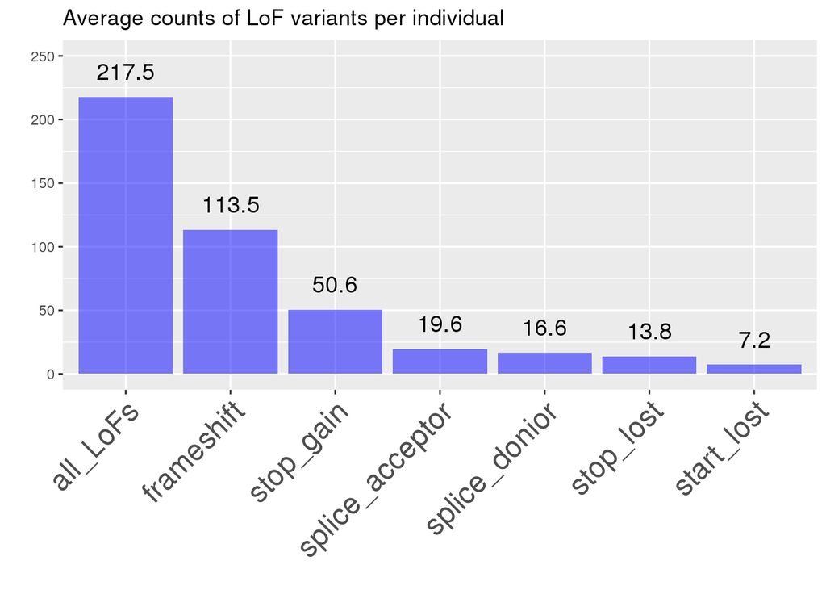

```r
# mean count of alleles per case in wecare
lof_wecare.mx <- wecare_genotypes.mx[lof,]
lof_wecare.counts <- apply(lof_wecare.mx, 2, sum, na.rm=TRUE)
lof_wecare.mean <- mean(lof_wecare.counts, na.rm=TRUE) # ~217
rm(lof_wecare.mx, lof_wecare.counts)

# ------- Plot average counts of lof-s per individual ------- #

# Summary table with average numbers of lof-s per individual
lof_summary_counts.df <- as.data.frame(cbind(
  lof_type=c("splice_acceptor", "splice_donior", "stop_gain", "stop_lost", "start_lost", "frameshift", "all_LoFs"),
  lof_count=c(sav_wecare.mean, sdv_wecare.mean, stogv_wecare.mean, stolv_wecare.mean, stalv_wecare.mean, fsv_wecare.mean, lof_wecare.mean)))

lof_summary_counts.df$lof_count <- as.numeric(as.vector(lof_summary_counts.df$lof_count))
lof_summary_counts.df <- lof_summary_counts.df %>% arrange(desc(lof_count))

# Order of levels defines order of bars on the plot
lof_summary_counts.df$lof_type <- factor(lof_summary_counts.df$lof_type,
  levels=c("all_LoFs", "frameshift", "stop_gain", "splice_acceptor", "splice_donior", "stop_lost", "start_lost"))

# Plot
ggplot(lof_summary_counts.df, aes(lof_type, lof_count)) +
  geom_bar(stat="identity", fill="blue", alpha=0.5) +
  geom_text(aes(label=round(lof_count,1)), vjust=-1, size=5)+
  labs(x = "", y = "") +
  ylim(0,250) +
  theme(axis.text.x = element_text(hjust=1, size=18, angle=45)) +
  ggtitle("Average counts of LoF variants per individual")
```

```r
# Clean-up
rm(splice_acceptor_variant, splice_donor_variant, stop_gain, frameshift_variant, stop_lost,
   start_lost, sav_wecare.mean, sdv_wecare.mean, stogv_wecare.mean, stolv_wecare.mean,
   stalv_wecare.mean, fsv_wecare.mean, lof_summary_counts.df)
```

## make_missense_index

Selecting ~379 missence variants per individual both: [ deleterious by SIFT ] AND [ probably_damaging by PolyPhen ]

```r
missense_all <- grepl( "missense_variant", wecare_variants.df$Consequence)
sum(missense_all) # 83,299
```

```
## [1] 83299
```

```r
summary(wecare_variants.df$SIFT_call)
```

```
##                deleterious deleterious_low_confidence
##                      28388                       2566
##                  tolerated   tolerated_low_confidence
##                      41732                       4097
##                       NA's
##                     144029
```

```r
# note many NAs; these are when SIFT is irrelevant (e.g. non-coding)?
deleterious <- wecare_variants.df$SIFT_call == "deleterious"
summary(deleterious)
```

```
##    Mode   FALSE    TRUE    NA's
## logical   48395   28388  144029
```

```r
FALSE -> deleterious[is.na(deleterious)]
summary(deleterious) # 28,388
```

```
##    Mode   FALSE    TRUE    NA's
## logical  192424   28388       0
```

```r
summary(wecare_variants.df$PolyPhen_call)
```

```
##            benign possibly_damaging probably_damaging           unknown
##             49227             12993             18369              2413
##              NA's
##            137810
```

```r
# note many NAs; these are when PolyPhen is irrelevant (e.g. non-coding)?
probably_damaging <- wecare_variants.df$PolyPhen_call == "probably_damaging"
summary(probably_damaging)
```

```
##    Mode   FALSE    TRUE    NA's
## logical   64633   18369  137810
```

```r
FALSE -> probably_damaging[is.na(probably_damaging)]
summary(probably_damaging) # 18,369
```

```
##    Mode   FALSE    TRUE    NA's
## logical  202443   18369       0
```

```r
missense <- deleterious & probably_damaging
sum(missense) # 13,417
```

```
## [1] 13417
```

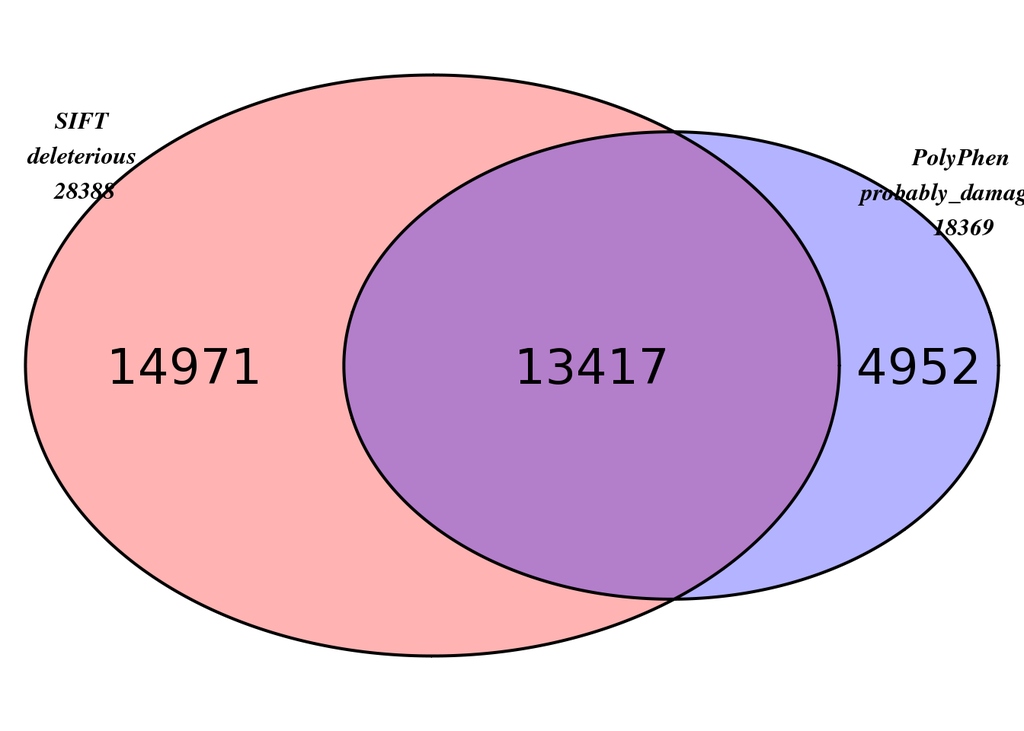

```
## (polygon[GRID.polygon.44], polygon[GRID.polygon.45], polygon[GRID.polygon.46], polygon[GRID.polygon.47], text[GRID.text.48], text[GRID.text.49], text[GRID.text.50], text[GRID.text.51], text[GRID.text.52])
```

```r
# Plot venn diagram of selected variants by types
grid.newpage()
draw.pairwise.venn(
  area1=sum(deleterious),
  area2=sum(probably_damaging),
  cross.area=sum(missense),
  category=c(
    paste("SIFT\ndeleterious\n", sum(deleterious)),
    paste("PolyPhen\nprobably_damaging\n", sum(probably_damaging))),
  fill=c("red", "blue"),
  alpha = c(0.3, 0.3),
  cex=2, cat.fontface=4, fontfamily=3)
```

```r
# mean count of missenses per case in wecare
missense_wecare.mx <- wecare_genotypes.mx[missense,]
missense_wecare.counts <- apply(missense_wecare.mx, 2, sum, na.rm=TRUE)
missense_wecare.mean <- mean(missense_wecare.counts, na.rm=TRUE)
missense_wecare.mean # ~379
```

```
## [1] 378.7447
```

```r
# Clean-up
rm(missense_all, deleterious, probably_damaging, missense_wecare.mx, missense_wecare.counts)
```

## make_clinsig_index

ClinSig version as reported by Ensembl v87-grch37_vep_cache (Jan2017, VEP script) ClinVar may become a better variant-annotation database, which may be used in future.

All *CLIN_SIG* annotations found in the file: “likely_benign”, “benign”, “likely_pathogenic”, “risk_factor”, “not_provided”, “uncertain_significance”, “pathogenic”, “association”, “protective”, “other”, “drug_response”

Note sums w/o na.rm=TRUE.

```r
selected_clinsig_terms <- c("likely_pathogenic", "risk_factor", "pathogenic", "association", "protective", "drug_response")

clinsig <- wecare_variants.df$CLIN_SIG %in% selected_clinsig_terms
sum(clinsig) # 717
```

```
## [1] 717
```

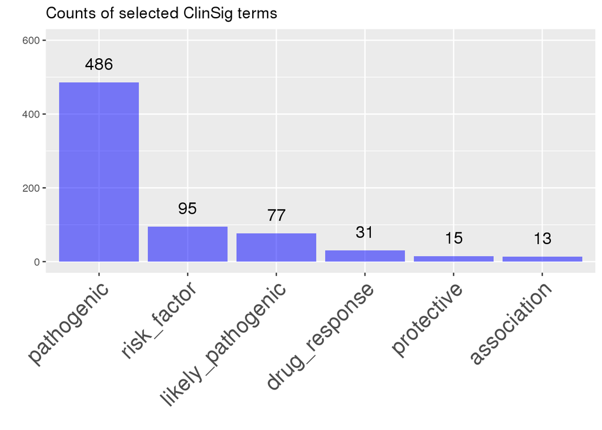

```r
x.df <- as.data.frame(table(as.vector(wecare_variants.df[clinsig,"CLIN_SIG"])))
c("type","count") -> colnames(x.df)
x.df$type <- factor(x.df$type,
  levels=c("pathogenic", "risk_factor", "likely_pathogenic", "drug_response", "protective", "association"))

ggplot(x.df, aes(type, count)) +
  geom_bar(stat="identity", fill="blue", alpha=0.5) +
  geom_text(aes(label=round(count,1)), vjust=-1, size=5)+
  labs(x = "", y = "") +
  ylim(0,600) +
  theme(axis.text.x = element_text(hjust=1, size=18, angle=45)) +
  ggtitle("Counts of selected ClinSig terms")
```

```r
# mean count of alleles per case in wecare
clinsig_wecare.mx <- wecare_genotypes.mx[clinsig,]
clinsig_wecare.counts <- apply(clinsig_wecare.mx, 2, sum, na.rm=TRUE)
clinsig_wecare.mean <- mean(clinsig_wecare.counts, na.rm=TRUE)
clinsig_wecare.mean # 78.8
```

```
## [1] 78.78481
```

```r
# Clean-up
rm(selected_clinsig_terms, clinsig_wecare.mx, clinsig_wecare.counts, x.df)
```

# — explore_selected —

## selected_types_per_individual_and_per_variantset

```r
# Count combinations of selectred categories
lof_missense <- lof & missense
clinsig_missense <- clinsig & missense
lof_clinsig <- lof & clinsig
lof_clinsig_missense <- lof_clinsig & missense

summary(lof_missense)
```

```
##    Mode   FALSE    TRUE    NA's
## logical  220802      10       0
```

```r
summary(clinsig_missense)
```

```
##    Mode   FALSE    TRUE    NA's
## logical  220608     204       0
```

```r
summary(lof_clinsig)
```

```
##    Mode   FALSE    TRUE    NA's
## logical  220714      98       0
```

```r
summary(lof_clinsig_missense)
```

```
##    Mode   FALSE    NA's
## logical  220812       0
```

```r
selected_variants <- lof | clinsig | missense

summary(selected_variants) # 17,598
```

```
##    Mode   FALSE    TRUE    NA's
## logical  203214   17598       0
```

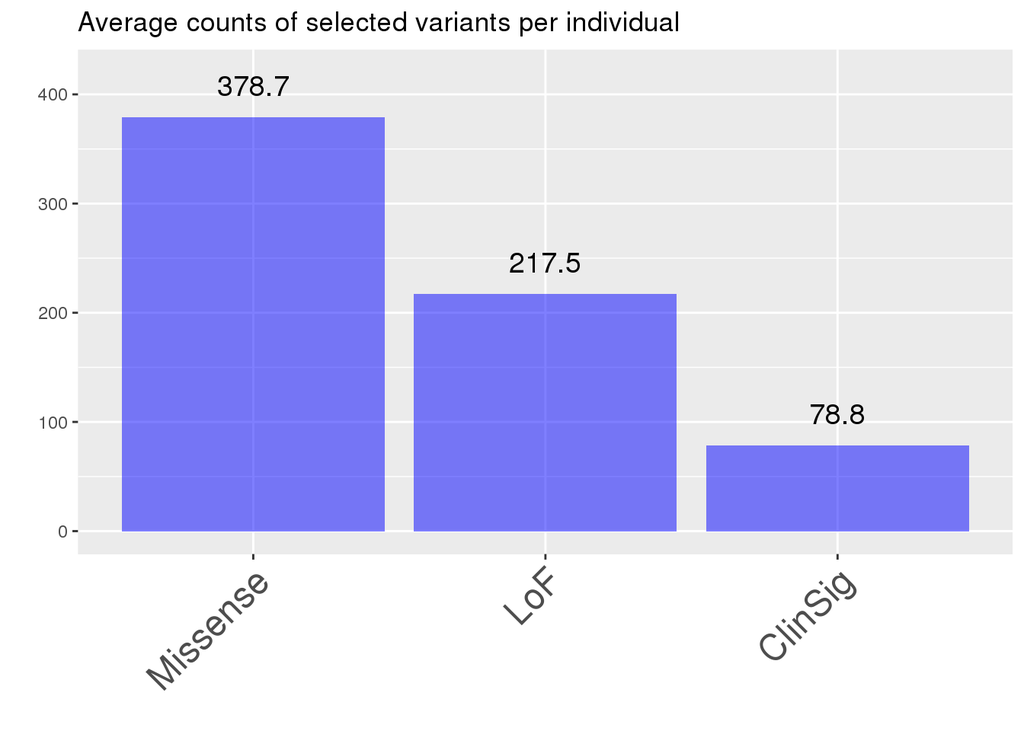

```r
# --- Plot mean counts of variant types per individual --- #

# Summary table with average numbers of protein-affecting per individual
summary_counts.df <- as.data.frame(cbind(
  type=c("Missense", "LoF", "ClinSig"),
  count=c(missense_wecare.mean, lof_wecare.mean, clinsig_wecare.mean)))

# Convert numbers to numeric vector
summary_counts.df$count <- as.numeric(as.vector(summary_counts.df$count))

# Order of levels defines order of bars on the plot
summary_counts.df$type <- factor(summary_counts.df$type,
  levels=c("Missense", "LoF", "ClinSig"))

# Plot bar diagramm of avg. count of selected types per individual
ggplot(summary_counts.df, aes(type, count)) +
  geom_bar(stat="identity", fill="blue", alpha=0.5) +
  geom_text(aes(label=round(count,1)), vjust=-1, size=5)+
  ylim(0, 420) +
  labs(x = "", y = "") +
  theme(axis.text.x = element_text(hjust=1, size=18, angle=45)) +
  ggtitle("Average counts of selected variants per individual")
```

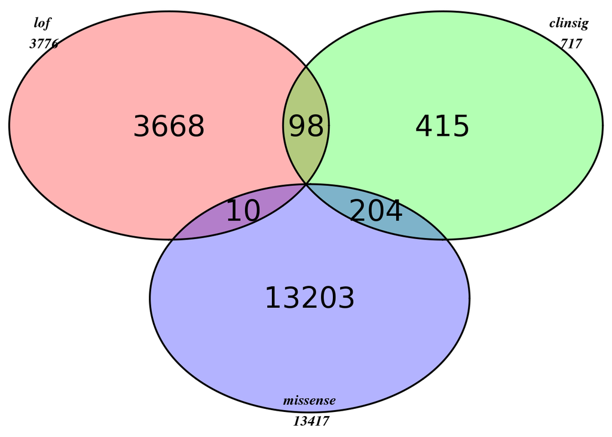

```
## (polygon[GRID.polygon.139], polygon[GRID.polygon.140], polygon[GRID.polygon.141], polygon[GRID.polygon.142], polygon[GRID.polygon.143], polygon[GRID.polygon.144], text[GRID.text.145], text[GRID.text.146], text[GRID.text.147], text[GRID.text.148], text[GRID.text.149], text[GRID.text.150], text[GRI…
```

```r
# Plot venn diagram of selected variants by types
grid.newpage()
draw.triple.venn(
  area1=sum(lof),
  area2=sum(clinsig),
  area3=sum(missense),
  n12=sum(lof_clinsig),
  n23=sum(clinsig_missense),
  n13=sum(lof_missense),
  n123=sum(lof_clinsig_missense),
  category=c(
    paste("lof\n", sum(lof)),
    paste("clinsig\n", sum(clinsig)),
    paste("missense\n", sum(missense))),
  fill = c("red", "green", "blue"),
  alpha = c(0.3, 0.3, 0.3),
  cex=2, cat.fontface=4, fontfamily=3)
```

```r
rm(summary_counts.df, missense_wecare.mean, lof_wecare.mean, clinsig_wecare.mean,
   lof, clinsig, missense, lof_clinsig, clinsig_missense, lof_missense, lof_clinsig_missense)
```

# keep_selected_variants_only

220,812 -> 17,598

```r
wecare_genotypes.mx <- wecare_genotypes.mx[selected_variants,]
wecare_variants.df <- wecare_variants.df[selected_variants,]
wecare_kgen.df <- wecare_kgen.df[selected_variants,]
wecare_exac.df <- wecare_exac.df[selected_variants,]

dim(wecare_genotypes.mx)
```

```
## [1] 17598   474
```

```r
dim(wecare_variants.df)
```

```
## [1] 17598    44
```

```r
dim(wecare_kgen.df)
```

```
## [1] 17598     9
```

```r
dim(wecare_exac.df)
```

```
## [1] 17598    48
```

```r
# Clean-up
rm(selected_variants)
```

# check_frequent_in_Kgen

These variants are preserved; However, they will require special treatment in downstream analysis

```r
x <- wecare_kgen.df$kgen.EUR_AF > 0.9
FALSE -> x[is.na(x)]
x <- wecare_kgen.df[x, "SplitVarID"]
x <- as.character(x)
length(x)
```

```
## [1] 19
```

```r
wecare_variants.df[unlist(x),c("SplitVarID","SYMBOL")]
```

```
##                SplitVarID        SYMBOL
## Var000015193 Var000015193           DBT
## Var000015846 Var000015846         PSRC1
## Var000016671 Var000016671        PTPN22
## Var000035434 Var000035434       FAM228B
## Var000055508 Var000055508       STK11IP
## Var000086777 Var000086777         ADH1B
## Var000094252 Var000094252       SLC45A2
## Var000132581 Var000132581        ZNF117
## Var000132591 Var000132591        ERV3-1
## Var000153820 Var000153820         MROH5
## Var000169838 Var000169838         ITIH5
## Var000230500 Var000230500       HEATR5A
## Var000248712 Var000248712 RP11-114H24.2
## Var000260856 Var000260856          BBS2
## Var000264746 Var000264746        PKD1L2
## Var000306192 Var000306192        ZNF221
## Var000310251 Var000310251        ZNF534
## Var000322457 Var000322457    AP000244.1
## Var000328275 Var000328275          HPS4
```

```r
y <- wecare_kgen.df$kgen.EUR_AF > 0.5
sum(y, na.rm=TRUE) # 147
```

```
## [1] 147
```

```r
rm(x,y)
```

# count_selected_multiallelic_varaints

439 multiallelics in selected varaints

```r
summary(wecare_variants.df$Multiallelic) # 439
```

```
##    Mode   FALSE    TRUE    NA's
## logical   17159     439       0
```

# count_variants_per_gene

```r
# Get number of genes
length(unique(wecare_variants.df$SYMBOL)) # 18,766
```

```
## [1] 8766
```

```r
# Look at the top genes
x <- sort(table(as.vector(wecare_variants.df$SYMBOL)), decreasing = TRUE)
x[1:200]
```

```
##
##    DNAH3    DNAH7  PDE4DIP   PKD1L2   MT-CYB     MUC4   MYO18B      ATM
##       25       23       20       20       19       15       15       14
##   COL6A6    DUOX2  PKHD1L1    TRPM1    C2CD3     CUBN   IGSF10    PKHD1
##       14       14       14       14       13       13       13       13
##    SPTA1    ABCC2    DCHS2    LAMA1     LRBA     POLG     POLQ     SPTB
##       13       12       12       12       12       12       12       12
##    ABCA4   CCDC66    LAMA2    MYO1A    MYO7A     NID2     NOD2     PLB1
##       11       11       11       11       11       11       11       11
##   PRUNE2   ZNF568    AMPD1    BRCA2    CES5A    ECT2L   FER1L6      FN1
##       11       11       10       10       10       10       10       10
##   KCNJ12      MPO    MYOM2     VWA8    A2ML1   ABCC11     ANK1    ATP7B
##       10       10       10       10        9        9        9        9
##  CCDC141   DNASE1      EPX   GPR113    KRT36    LAMB2    MCPH1    MKI67
##        9        9        9        9        9        9        9        9
##    MYH13     MYOF     NAV2    NLRP5    POMT1   SLC5A4    STAB2       TG
##        9        9        9        9        9        9        9        9
##      TNC   UNC45B   ZNF106    ABCA3    ABCB5      ACE ADAMTSL1    ALPK2
##        9        9        9        8        8        8        8        8
##     ASPM     ATIC       C9   CCHCR1     CCR5    CD109  COL28A1    CSMD3
##        8        8        8        8        8        8        8        8
##   DNAH14  EFCAB13    INADL KIAA1217    KRT75    LAMA4    LAMC3      LPA
##        8        8        8        8        8        8        8        8
##    LRRK2    MYH14    MYH15     MYH4    MYOM1     OCA2    PADI4   PCDH15
##        8        8        8        8        8        8        8        8
##     PCK2   PTPN13     SETX       SI   SPAG17     TEP1     TPTE    USP45
##        8        8        8        8        8        8        8        8
##     UTRN    WDR41     WFS1      WRN      XDH   ZNF268    ABCA8 ADAMTS14
##        8        8        8        8        8        8        7        7
##    AGBL1      AGL     ANO2  ATP13A5      BLK  CACNA1S   CAPN13    CDH23
##        7        7        7        7        7        7        7        7
##   CELSR2   CEP192    CHEK2    CNTLN  COL15A1      CR2  CTTNBP2    DAAM2
##        7        7        7        7        7        7        7        7
##   DNAH12    DNHD1   DOPEY2     DPYD   EGFLAM     ELP2    EPB41   ERV3-1
##        7        7        7        7        7        7        7        7
##     EXO1       F5   FRMPD1   GPRC6A     H6PD    IFIH1   IQGAP2 KIAA0556
##        7        7        7        7        7        7        7        7
##    LAMB4    LAMC2    LRRK1   MCM3AP     MLH3   MROH2B    MUC3A    MYO5C
##        7        7        7        7        7        7        7        7
##    MYO7B    NCOA3   NLRP12     NRAP    NRDE2    OGDHL    P2RX5   PDCD11
##        7        7        7        7        7        7        7        7
##    PDIA2     PHKB   PKD1L1   PLA2R1    PRIM2   PTCHD3     PYGL      PZP
##        7        7        7        7        7        7        7        7
##  RAPGEF3   RSPH4A   SETBP1  SLC10A2  SLC22A1   SLC3A1    SOGA2    SSFA2
##        7        7        7        7        7        7        7        7
##  TBC1D17    TEX15     TGM4 TIMELESS     TMC8  TMPRSS7  TRAPPC9    TTLL6
##        7        7        7        7        7        7        7        7
##  TUBGCP6    UGGT2     ULK4   UMODL1    UTP20    WDR27     WDR3   ZNF528
##        7        7        7        7        7        7        7        7
##      A2M    ABCB6   ABCC12   AKAP11  ALDH1B1     ALLC    ALPK1  ANKRD33
##        6        6        6        6        6        6        6        6
```

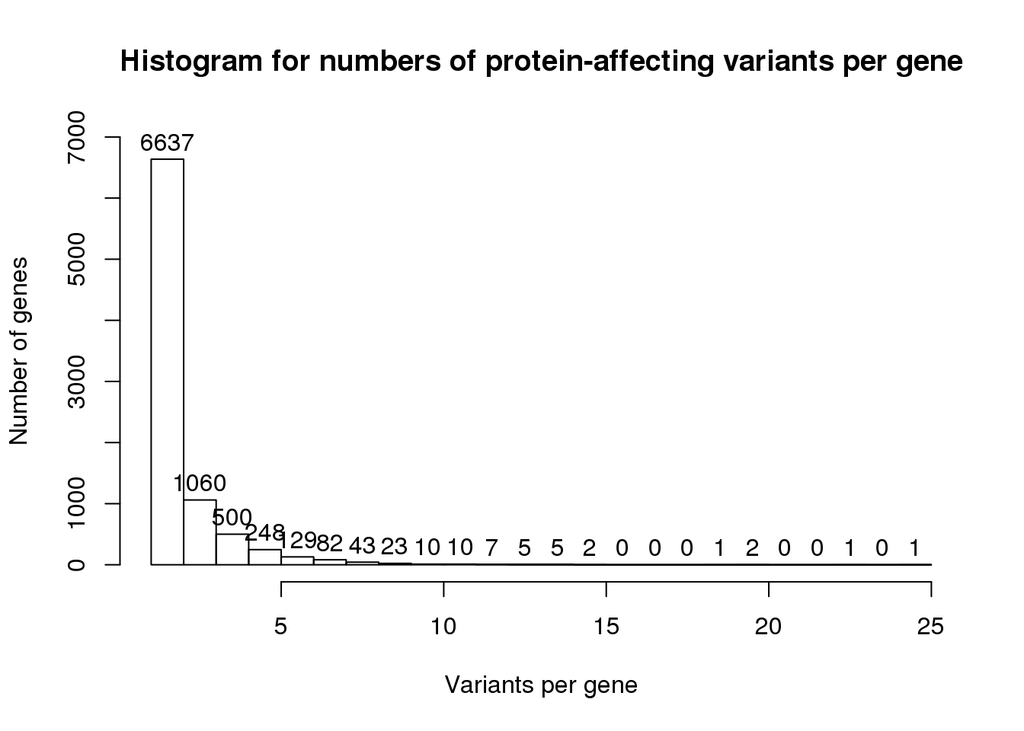

```r
# Save table of counts
y <- cbind(names(x),x)
c("gene","count") -> colnames(y)
write.table(y, file=paste(results_folder, "wecare_only_variants_per_gene.txt", sep="/"), quote = FALSE, row.names = FALSE)

# Plot histogram
z <- wecare_variants.df %>%  group_by(SYMBOL) %>% summarise(n())
"vars_count" -> colnames(z)[2]
hist(z$vars_count, main="Histogram for numbers of protein-affecting variants per gene", xlab="Variants per gene", ylab="Number of genes", ylim=c(0,7000), breaks=25, labels = TRUE)
```

```r
mean(z$vars_count) # 2.007529
```

```
## [1] 2.007529
```

```r
# Clean-up
rm(x,y,z)
```

# data_summary

```r
dim(wecare_genotypes.mx)
```

```
## [1] 17598   474
```

```r
class(wecare_genotypes.mx)
```

```
## [1] "matrix"
```

```r
wecare_genotypes.mx[1:5,1:5]
```

```
##              P1_A01 P1_A02 P1_A03 P1_A04 P1_A05
## Var000000026      0     NA      0      0      0
## Var000000029      0      0      0      0      0
## Var000000031      0      0      0      0      0
## Var000000053      0      0      0      0     NA
## Var000000064      0      0      0      0     NA
```

```r
dim(wecare_kgen.df)
```

```
## [1] 17598     9
```

```r
colnames(wecare_kgen.df)
```

```
## [1] "SplitVarID"  "kgen.AC"     "kgen.AN"     "kgen.AF"     "kgen.AFR_AF"
## [6] "kgen.AMR_AF" "kgen.EAS_AF" "kgen.EUR_AF" "kgen.SAS_AF"
```

```r
wecare_kgen.df[1:5,1:5]
```

```
##                SplitVarID kgen.AC kgen.AN     kgen.AF kgen.AFR_AF
## Var000000026 Var000000026      NA      NA          NA          NA
## Var000000029 Var000000029       1    5008 0.000199681           0
## Var000000031 Var000000031       1    5008 0.000199681           0
## Var000000053 Var000000053      NA      NA          NA          NA
## Var000000064 Var000000064      NA      NA          NA          NA
```

```r
dim(wecare_exac.df)
```

```
## [1] 17598    48
```

```r
colnames(wecare_exac.df)
```

```
##  [1] "SplitVarID"              "exac_non_TCGA.AF"
##  [3] "exac_non_TCGA.AC"        "exac_non_TCGA.AN"
##  [5] "exac_non_TCGA.AC_FEMALE" "exac_non_TCGA.AN_FEMALE"
##  [7] "exac_non_TCGA.AC_MALE"   "exac_non_TCGA.AN_MALE"
##  [9] "exac_non_TCGA.AC_Adj"    "exac_non_TCGA.AN_Adj"
## [11] "exac_non_TCGA.AC_Hom"    "exac_non_TCGA.AC_Het"
## [13] "exac_non_TCGA.AC_Hemi"   "exac_non_TCGA.AC_AFR"
## [15] "exac_non_TCGA.AN_AFR"    "exac_non_TCGA.Hom_AFR"
## [17] "exac_non_TCGA.Het_AFR"   "exac_non_TCGA.Hemi_AFR"
## [19] "exac_non_TCGA.AC_AMR"    "exac_non_TCGA.AN_AMR"
## [21] "exac_non_TCGA.Hom_AMR"   "exac_non_TCGA.Het_AMR"
## [23] "exac_non_TCGA.Hemi_AMR"  "exac_non_TCGA.AC_EAS"
## [25] "exac_non_TCGA.AN_EAS"    "exac_non_TCGA.Hom_EAS"
## [27] "exac_non_TCGA.Het_EAS"   "exac_non_TCGA.Hemi_EAS"
## [29] "exac_non_TCGA.AC_FIN"    "exac_non_TCGA.AN_FIN"
## [31] "exac_non_TCGA.Hom_FIN"   "exac_non_TCGA.Het_FIN"
## [33] "exac_non_TCGA.Hemi_FIN"  "exac_non_TCGA.AC_NFE"
## [35] "exac_non_TCGA.AN_NFE"    "exac_non_TCGA.Hom_NFE"
## [37] "exac_non_TCGA.Het_NFE"   "exac_non_TCGA.Hemi_NFE"
## [39] "exac_non_TCGA.AC_SAS"    "exac_non_TCGA.AN_SAS"
## [41] "exac_non_TCGA.Hom_SAS"   "exac_non_TCGA.Het_SAS"
## [43] "exac_non_TCGA.Hemi_SAS"  "exac_non_TCGA.AC_OTH"
## [45] "exac_non_TCGA.AN_OTH"    "exac_non_TCGA.Hom_OTH"
## [47] "exac_non_TCGA.Het_OTH"   "exac_non_TCGA.Hemi_OTH"
```

```r
wecare_exac.df[1:5,1:5]
```

```
##                SplitVarID exac_non_TCGA.AF exac_non_TCGA.AC
## Var000000026 Var000000026               NA               NA
## Var000000029 Var000000029        1.506e-04               16
## Var000000031 Var000000031        2.354e-04               25
## Var000000053 Var000000053        1.883e-05                2
## Var000000064 Var000000064        9.416e-06                1
##              exac_non_TCGA.AN exac_non_TCGA.AC_FEMALE
## Var000000026               NA                      NA
## Var000000029           106210                       8
## Var000000031           106210                       4
## Var000000053           106210                       0
## Var000000064           106206                       0
```

```r
dim(wecare_variants.df)
```

```
## [1] 17598    44
```

```r
str(wecare_variants.df)
```

```
## 'data.frame':    17598 obs. of  44 variables:
##  $ SplitVarID        : Factor w/ 343824 levels "Var000000001",..: 26 29 31 53 64 167 191 227 237 300 ...
##  $ SYMBOL            : Factor w/ 19862 levels "A1BG","A1CF",..: 11149 11149 11149 8665 8665 540 540 540 540 18233 ...
##  $ TYPE              : Factor w/ 2 levels "INDEL","SNP": 2 2 2 2 2 2 2 2 2 2 ...
##  $ CHROM             : Factor w/ 25 levels "1","10","11",..: 1 1 1 1 1 1 1 1 1 1 ...
##  $ POS               : int  881871 883883 883946 897287 897792 979748 982844 987173 989899 1132513 ...
##  $ REF               : Factor w/ 2142 levels "A","AAAAAAAAAAAAAAAAAAAAAAAG",..: 1044 1575 539 539 539 1 1044 1575 539 539 ...
##  $ ALT               : Factor w/ 1297 levels "A","AAAAAAAAAAAAACT",..: 1 323 989 989 989 989 323 664 989 989 ...
##  $ AC                : int  1 2 1 1 1 53 106 1 1 2 ...
##  $ AF                : num  0.000711 0.001555 0.000774 0.000711 0.000722 ...
##  $ AN                : int  1406 1286 1292 1406 1386 1416 1388 1420 1414 1320 ...
##  $ Consequence       : Factor w/ 78 levels "3_prime_UTR_variant",..: 66 28 28 28 66 28 24 28 28 28 ...
##  $ SIFT_call         : Factor w/ 4 levels "deleterious",..: NA 1 1 1 NA 1 NA 1 1 1 ...
##  $ SIFT_score        : num  NA 0 0.01 0.04 NA 0.01 NA 0 0.02 0.02 ...
##  $ PolyPhen_call     : Factor w/ 4 levels "benign","possibly_damaging",..: NA 3 3 3 NA 3 NA 3 3 3 ...
```

[output cut: 30 more lines]

```r
wecare_variants.df[1:5,1:5]
```

```
##                SplitVarID SYMBOL TYPE CHROM    POS
## Var000000026 Var000000026  NOC2L  SNP     1 881871
## Var000000029 Var000000029  NOC2L  SNP     1 883883
## Var000000031 Var000000031  NOC2L  SNP     1 883946
## Var000000053 Var000000053 KLHL17  SNP     1 897287
## Var000000064 Var000000064 KLHL17  SNP     1 897792
```

```r
dim(wecare_phenotypes.df)
```

```
## [1] 474  32
```

```r
str(wecare_phenotypes.df)
```

```
## 'data.frame':    474 obs. of  32 variables:
##  $ wes_id        : chr  "P1_A01" "P1_A02" "P1_A03" "P1_A04" ...
##  $ gwas_id       : chr  "id203568" "id357807" "id325472" "id304354" ...
##  $ merged_id     : chr  "P1_A01_id203568" "P1_A02_id357807" "P1_A03_id325472" "P1_A04_id304354" ...
##  $ filter        : chr  "pass" "pass" "pass" "pass" ...
##  $ cc            : num  1 1 1 1 1 1 0 1 1 0 ...
##  $ setno         : int  203568 357807 325472 304354 222648 244843 276284 297810 250898 226974 ...
##  $ registry      : chr  "IR" "LA" "IA" "IA" ...
##  $ family_history: int  1 0 1 1 1 1 1 1 1 0 ...
##  $ age_dx        : int  49 35 32 33 44 28 28 38 35 36 ...
##  $ age_ref       : num  58 36 41 34 49 28 32 44 35 38 ...
##  $ rstime        : num  10.17 1.83 9.75 1.59 5.66 ...
##  $ eig1_gwas     : num  -0.00389 -0.00379 -0.01011 -0.01288 -0.01086 ...
##  $ eig2_gwas     : num  0.00266 0.00246 -0.0001 0.00595 0.01157 ...
##  $ eig3_gwas     : num  0.06803 0.05055 -0.00603 0.00747 0.00144 ...
```

[output cut: 18 more lines]

```r
wecare_phenotypes.df[1:5,1:5]
```

```
##        wes_id  gwas_id       merged_id filter cc
## P1_A01 P1_A01 id203568 P1_A01_id203568   pass  1
## P1_A02 P1_A02 id357807 P1_A02_id357807   pass  1
## P1_A03 P1_A03 id325472 P1_A03_id325472   pass  1
## P1_A04 P1_A04 id304354 P1_A04_id304354   pass  1
## P1_A05 P1_A05 id222648 P1_A05_id222648   pass  1
```

```r
# Check consistency of rownames and colnames
sum(colnames(wecare_genotypes.mx) != rownames(wecare_phenotypes.df))
```

```
## [1] 0
```

```r
sum(rownames(wecare_genotypes.mx) != rownames(wecare_kgen.df))
```

```
## [1] 0
```

```r
sum(rownames(wecare_genotypes.mx) != rownames(wecare_exac.df))
```

```
## [1] 0
```

```r
sum(rownames(wecare_genotypes.mx) != rownames(wecare_variants.df))
```

```
## [1] 0
```

# save_data

```r
save.image(paste(interim_data_folder, "s07a_filter_by_variant_effect_wecare_only_jan2017.RData", sep="/"))
```

# final_section

```r
ls()
```

```
## [1] "interim_data_folder"  "results_folder"       "wecare_exac.df"
## [4] "wecare_genotypes.mx"  "wecare_kgen.df"       "wecare_phenotypes.df"
## [7] "wecare_variants.df"
```

```r
Sys.time()
```

```
## [1] "2017-03-06 22:17:18 GMT"
```